# Lab Assignment Four: Evaluation and Multi-Layer Perceptron

### Group Members: Yifu Zhang, Yue Li, Weiyi Zhao, Siwei Wang Date: Oct. 3, 2018

## 1. Preparation

### 1.1 Data Description and task classification

#### 1.1.1 Introduction

Everyone is talking about the amazing wine quality you can find from Portugal. But not everyone knows what exactly they are. Wine certification is generally assessed by physicochemical and sensory tests. It’s really complicated and not easy to understand. What if the quality was given by a straightforward score range from 0 to 10? Or simply by their level such as classical, premium, and luxury? In this project, we dedicate to propose an algorithm to predict the wine quality. Multi-layer perceptron is used to build the model which predict the quality of wine based on the wine's physicochemicales test results.

#### 1.1.2 Data Description

The data we used was obtained through UCI Machine Learning Repository. The two datasets in the original link are related to red and white variants of the Portuguese "Vinho Verde" wine. In this project, we only use the white wine dataset to build our model. This dataset contains 12 variables. But not all input variables are relevant to our model. We will perform the variable selection in the late analysis. Also, this dataset contains an important information on wine scoring. Wine samples were evaluated by wine experts. And wine quality scores range from 0 (very bad) to 10 (very excellent). We will set our classes according to these scores. Our data only range form score 3 to 9. So we set score 3 to level 1, score 4 to level 2 and so on. The highest level is level 7 and stands for score 9.

#### 1.1.3 Study Purpose

In this project, we developed a model for the wine quality classification using the dataset acquired from UCI Machine Learning Repository. The objective of the model is to benefit both wine certification entities, wine producers or suppliers, and personal buyers in evaluating wine qualities by outputting wine quality levels. The detailed benefits for wine certification entities, wine producer or supplier, and personal buyers are respectively shown as follows:

**For wine certification entities:** Our model can be used as a supplementary tool for oenologist’s wine evaluation. This model may help them make more accurate and efficient evaluations regarding wine qualities.

**For wine producers or suppliers:** For the wine producers, our model could give them a clear idea on factors affecting the wine quality and potentially help them improve the wine quality resulting in saving time on production process. For suppliers, this model acts as a criterion for pricing. The supplier can use this model to set their marketing strategy and making profit on the product.

**For personal buyers:** Most of the personal buyers are not like the oenologist who is really know how to distinguish the wine quality. This model could give them out a straightforward wine qulity levels to help them find a wine that meet their preference and their budgets. Also, the level of wine usually have a positive relationship with the wine price. Personal buyer can use the level of the wine to find a wine under their budget.

### 1.2 Data preparation

```python
import pandas as ps
import plotly as pt
import sklearn as sk
import seaborn as sns
from sklearn.cross_validation import train_test_split
from sklearn.metrics import accuracy_score
from sklearn.linear_model import LogisticRegression as SKLogisticRegression
import time
import pandas as pd
csv = pd.read_csv("https://archive.ics.uci.edu/ml/machine-learning-databases/wine-quality/winequality-white.csv",  delimiter=';')
print(csv.columns)
```

```
Index(['fixed acidity', 'volatile acidity', 'citric acid', 'residual sugar',
       'chlorides', 'free sulfur dioxide', 'total sulfur dioxide', 'density',
       'pH', 'sulphates', 'alcohol', 'quality'],
      dtype='object')
```

```python
csv.columns = ['FixedAcidity', 'VolatileAcidity', 'CitricAcid', 'ResidualSugar', 'Chlorides', 'FreeSulfurDioxide', 'TotalSulfurDioxide', 'Density', 'PH', 'Sulphates', 'Alcohol', 'Quality']
csv.describe()
```

|  | FixedAcidity | VolatileAcidity | CitricAcid | ResidualSugar | Chlorides | FreeSulfurDioxide | TotalSulfurDioxide | Density | PH | Sulphates | Alcohol | Quality |
| --- | --- | --- | --- | --- | --- | --- | --- | --- | --- | --- | --- | --- |
| count | 4898.000000 | 4898.000000 | 4898.000000 | 4898.000000 | 4898.000000 | 4898.000000 | 4898.000000 | 4898.000000 | 4898.000000 | 4898.000000 | 4898.000000 | 4898.000000 |
| mean | 6.854788 | 0.278241 | 0.334192 | 6.391415 | 0.045772 | 35.308085 | 138.360657 | 0.994027 | 3.188267 | 0.489847 | 10.514267 | 5.877909 |
| std | 0.843868 | 0.100795 | 0.121020 | 5.072058 | 0.021848 | 17.007137 | 42.498065 | 0.002991 | 0.151001 | 0.114126 | 1.230621 | 0.885639 |
| min | 3.800000 | 0.080000 | 0.000000 | 0.600000 | 0.009000 | 2.000000 | 9.000000 | 0.987110 | 2.720000 | 0.220000 | 8.000000 | 3.000000 |
| 25% | 6.300000 | 0.210000 | 0.270000 | 1.700000 | 0.036000 | 23.000000 | 108.000000 | 0.991723 | 3.090000 | 0.410000 | 9.500000 | 5.000000 |
| 50% | 6.800000 | 0.260000 | 0.320000 | 5.200000 | 0.043000 | 34.000000 | 134.000000 | 0.993740 | 3.180000 | 0.470000 | 10.400000 | 6.000000 |
| 75% | 7.300000 | 0.320000 | 0.390000 | 9.900000 | 0.050000 | 46.000000 | 167.000000 | 0.996100 | 3.280000 | 0.550000 | 11.400000 | 6.000000 |
| max | 14.200000 | 1.100000 | 1.660000 | 65.800000 | 0.346000 | 289.000000 | 440.000000 | 1.038980 | 3.820000 | 1.080000 | 14.200000 | 9.000000 |

```python
!pip install missingno
```

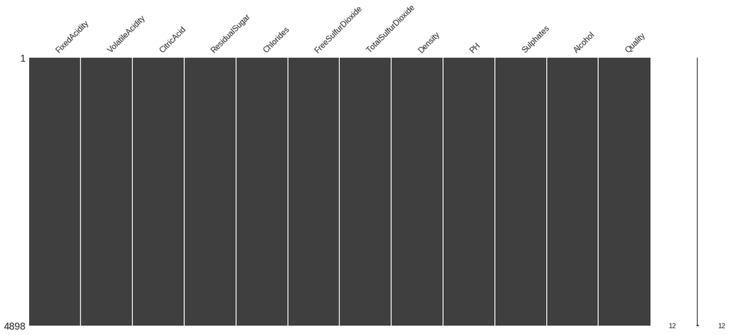

```python
import missingno as mn
import matplotlib.pyplot as plt
mn.matrix(csv.sort_values(by=["Quality"]))
plt.show()
```

```python
csv.info()
```

```
<class 'pandas.core.frame.DataFrame'>
RangeIndex: 4898 entries, 0 to 4897
Data columns (total 12 columns):
FixedAcidity          4898 non-null float64
VolatileAcidity       4898 non-null float64
CitricAcid            4898 non-null float64
ResidualSugar         4898 non-null float64
Chlorides             4898 non-null float64
FreeSulfurDioxide     4898 non-null float64
TotalSulfurDioxide    4898 non-null float64
Density               4898 non-null float64
PH                    4898 non-null float64
Sulphates             4898 non-null float64
Alcohol               4898 non-null float64
Quality               4898 non-null int64
dtypes: float64(11), int64(1)
memory usage: 459.3 KB
```

```python
csv['Quality'].value_counts()
```

```
6    2198
5    1457
7     880
8     175
4     163
3      20
9       5
Name: Quality, dtype: int64
```

```python
csv["Quality"].describe()
```

```
count    4898.000000
mean        5.877909
std         0.885639
min         3.000000
25%         5.000000
50%         6.000000
75%         6.000000
max         9.000000
Name: Quality, dtype: float64
```

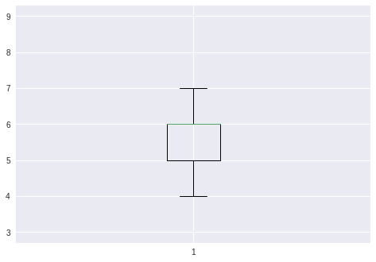

```python
import matplotlib.pyplot as plt
import numpy as np
plt.boxplot(csv["Quality"])
plt.show()
```

```python
def label_quality (row):
   if row['Quality'] == 3:
      return 1
   elif row['Quality'] == 4:
      return 2
   elif row['Quality'] == 5:
      return 3
   elif row['Quality'] == 6:
      return 4
   elif row['Quality'] == 7:
      return 5
   elif row['Quality'] == 8:
      return 6
   elif row['Quality'] == 9:
      return 7
csv['Quality'] =csv.apply (lambda row: label_quality (row),axis=1)
csv['Quality'].value_counts()
```

```
4    2198
3    1457
5     880
6     175
2     163
1      20
7       5
Name: Quality, dtype: int64
```

In our previous project, we set 3 classification classes such as score 3 -4 as classical, score 5-7 as premium and score 8-9 as luxury. However, in that way out prediction result can provide less refence for our target customer. For that reason, in this project, we set our data to 7 prediction classes. Such as we set score 3 to level 1, score 4 to level 2 and so on. The highest level is level 7 and stands for score 9. In that way we feel that the unbalnced classes will have less effect on the prediction result of our model. Also, our prediction result will has much more practical significance on our study purpose.

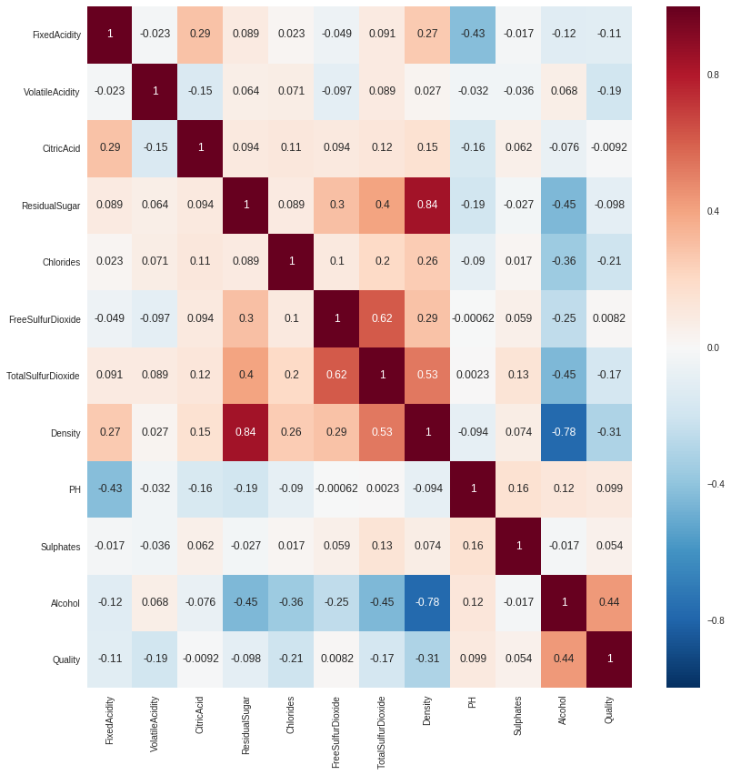

```python
f, ax = plt.subplots(figsize=(12, 12))

sns.heatmap(csv.corr(), annot=True, center=0)

f.tight_layout()
```

According to heat map, variables with correlation absolute values smaller than 0.1 will be consided as non-effective variables and be dropped. Variables with correlation absolute values larger than 0.5 with be consided as effective variables and be added to later model. We consider the rest of variables could possibly affect the result of wine quality, thus produce further analysis on them.

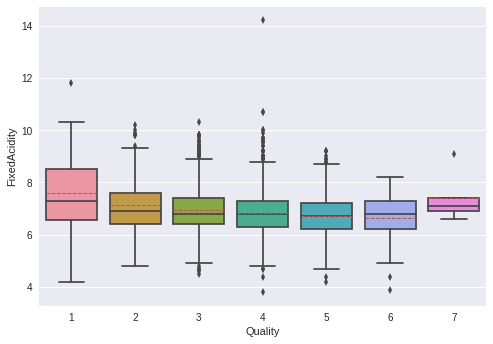

```python
sns.boxplot(x='Quality',y='FixedAcidity',data=csv,meanline=True,showmeans=True)
plt.show()
```

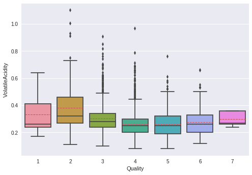

```python
sns.boxplot(x='Quality',y='VolatileAcidity',data=csv,meanline=True,showmeans=True)
plt.show()
```

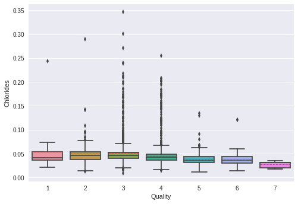

```python
sns.boxplot(x='Quality',y='Chlorides',data=csv,meanline=True,showmeans=True)
plt.show()
```

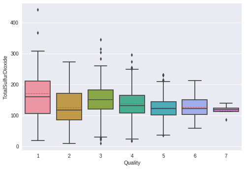

```python
sns.boxplot(x='Quality',y='TotalSulfurDioxide',data=csv,meanline=True,showmeans=True)
plt.show()
```

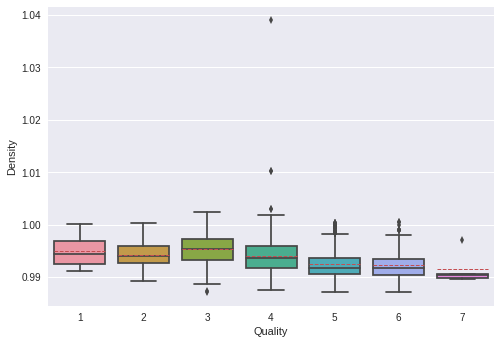

```python
sns.boxplot(x='Quality',y='Density',data=csv,meanline=True,showmeans=True)
plt.show()
```

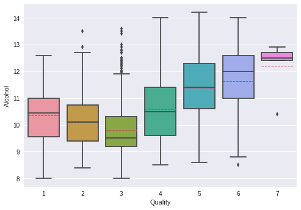

```python
sns.boxplot(x='Quality',y='Alcohol',data=csv,meanline=True,showmeans=True)
plt.show()
```

```python
csvdrop = csv.drop(['PH','CitricAcid','ResidualSugar','FreeSulfurDioxide','Sulphates'],axis=1)
np.seterr(divide='ignore', invalid='ignore', over='ignore')
csvdrop.info()
```

```
<class 'pandas.core.frame.DataFrame'>
RangeIndex: 4898 entries, 0 to 4897
Data columns (total 7 columns):
FixedAcidity          4898 non-null float64
VolatileAcidity       4898 non-null float64
Chlorides             4898 non-null float64
TotalSulfurDioxide    4898 non-null float64
Density               4898 non-null float64
Alcohol               4898 non-null float64
Quality               4898 non-null int64
dtypes: float64(6), int64(1)
memory usage: 267.9 KB
```

```python
csvdrop.head(50)
```

|  | FixedAcidity | VolatileAcidity | Chlorides | TotalSulfurDioxide | Density | Alcohol | Quality |
| --- | --- | --- | --- | --- | --- | --- | --- |
| 0 | 7.0 | 0.27 | 0.045 | 170.0 | 1.0010 | 8.8 | 4 |
| 1 | 6.3 | 0.30 | 0.049 | 132.0 | 0.9940 | 9.5 | 4 |
| 2 | 8.1 | 0.28 | 0.050 | 97.0 | 0.9951 | 10.1 | 4 |
| 3 | 7.2 | 0.23 | 0.058 | 186.0 | 0.9956 | 9.9 | 4 |
| 4 | 7.2 | 0.23 | 0.058 | 186.0 | 0.9956 | 9.9 | 4 |
| 5 | 8.1 | 0.28 | 0.050 | 97.0 | 0.9951 | 10.1 | 4 |
| 6 | 6.2 | 0.32 | 0.045 | 136.0 | 0.9949 | 9.6 | 4 |
| 7 | 7.0 | 0.27 | 0.045 | 170.0 | 1.0010 | 8.8 | 4 |
| 8 | 6.3 | 0.30 | 0.049 | 132.0 | 0.9940 | 9.5 | 4 |
| 9 | 8.1 | 0.22 | 0.044 | 129.0 | 0.9938 | 11.0 | 4 |
| 10 | 8.1 | 0.27 | 0.033 | 63.0 | 0.9908 | 12.0 | 3 |
| 11 | 8.6 | 0.23 | 0.035 | 109.0 | 0.9947 | 9.7 | 3 |
| 12 | 7.9 | 0.18 | 0.040 | 75.0 | 0.9920 | 10.8 | 3 |
| 13 | 6.6 | 0.16 | 0.044 | 143.0 | 0.9912 | 12.4 | 5 |
| 14 | 8.3 | 0.42 | 0.040 | 172.0 | 1.0002 | 9.7 | 3 |
| 15 | 6.6 | 0.17 | 0.032 | 112.0 | 0.9914 | 11.4 | 5 |
| 16 | 6.3 | 0.48 | 0.046 | 99.0 | 0.9928 | 9.6 | 4 |
| 17 | 6.2 | 0.66 | 0.029 | 75.0 | 0.9892 | 12.8 | 6 |
| 18 | 7.4 | 0.34 | 0.033 | 171.0 | 0.9917 | 11.3 | 4 |
| 19 | 6.5 | 0.31 | 0.044 | 133.0 | 0.9955 | 9.5 | 3 |
| 20 | 6.2 | 0.66 | 0.029 | 75.0 | 0.9892 | 12.8 | 6 |
| 21 | 6.4 | 0.31 | 0.038 | 102.0 | 0.9912 | 11.0 | 5 |
| 22 | 6.8 | 0.26 | 0.049 | 122.0 | 0.9930 | 10.5 | 6 |
| 23 | 7.6 | 0.67 | 0.074 | 168.0 | 0.9937 | 9.3 | 3 |
| 24 | 6.6 | 0.27 | 0.052 | 142.0 | 0.9951 | 10.0 | 4 |
| 25 | 7.0 | 0.25 | 0.046 | 245.0 | 0.9955 | 10.4 | 4 |
| 26 | 6.9 | 0.24 | 0.052 | 146.0 | 0.9930 | 10.0 | 4 |
| 27 | 7.0 | 0.28 | 0.051 | 141.0 | 0.9961 | 10.5 | 4 |
| 28 | 7.4 | 0.27 | 0.047 | 132.0 | 0.9914 | 11.6 | 4 |
| 29 | 7.2 | 0.32 | 0.033 | 114.0 | 0.9906 | 12.3 | 5 |
| 30 | 8.5 | 0.24 | 0.044 | 142.0 | 0.9974 | 10.0 | 4 |
| 31 | 8.3 | 0.14 | 0.042 | 47.0 | 0.9934 | 10.2 | 4 |
| 32 | 7.4 | 0.25 | 0.050 | 100.0 | 0.9920 | 10.8 | 4 |
| 33 | 6.2 | 0.12 | 0.045 | 117.0 | 0.9939 | 9.0 | 4 |
| 34 | 5.8 | 0.27 | 0.044 | 179.0 | 0.9962 | 10.2 | 3 |
| 35 | 7.3 | 0.28 | 0.080 | 123.0 | 0.9905 | 12.8 | 3 |
| 36 | 6.5 | 0.39 | 0.051 | 149.0 | 0.9934 | 10.0 | 3 |
| 37 | 7.0 | 0.33 | 0.053 | 138.0 | 0.9906 | 11.2 | 4 |
| 38 | 7.3 | 0.24 | 0.057 | 149.0 | 0.9999 | 8.6 | 3 |
| 39 | 7.3 | 0.24 | 0.057 | 149.0 | 0.9999 | 8.6 | 3 |
| 40 | 6.7 | 0.23 | 0.172 | 158.0 | 0.9937 | 9.4 | 4 |
| 41 | 6.7 | 0.24 | 0.173 | 157.0 | 0.9937 | 9.4 | 4 |
| 42 | 7.0 | 0.31 | 0.069 | 160.0 | 0.9954 | 9.8 | 4 |
| 43 | 6.6 | 0.24 | 0.057 | 152.0 | 0.9934 | 9.5 | 4 |
| 44 | 6.7 | 0.23 | 0.060 | 154.0 | 0.9934 | 9.5 | 4 |
| 45 | 7.4 | 0.18 | 0.058 | 167.0 | 0.9931 | 10.0 | 5 |
| 46 | 6.2 | 0.45 | 0.063 | 206.0 | 0.9940 | 9.8 | 2 |
| 47 | 6.2 | 0.46 | 0.066 | 207.0 | 0.9939 | 9.8 | 3 |
| 48 | 7.0 | 0.31 | 0.069 | 160.0 | 0.9954 | 9.8 | 4 |
| 49 | 6.9 | 0.19 | 0.067 | 150.0 | 0.9950 | 9.8 | 3 |

From each boxplot above, we can see that although some variables do not have high correlation value, the distributions between different groups showed notable differences. Therefore we consider these variables at least have some effect on specific groups and cannot be dropped. Thus we only drop those variables with absolute correlation values less than 0.1 and make a new dataset. The new dataset contains 7 variables: "FixedAcidity","VolatileAcidity", "Chlorides","TotalSulfurDoxide", "Density", "Alcohol" and "Quality".

## 2. Evaluation

### 2.1 Evaluation Metric

As for evaluation metric, first thing comes into mind is classification accuracy. But it is not always the right choice. Evaluation metric should help us to decide whether our model is good enough to solve our problem. Considering the imbalance between classes in our data, it is obvious that classification accuracy will not give us enough information to make this decision.

Besides classification accuracy, there are three other performance-measuring methods most commonly used: Precision, Recall and F1-score.

**Precision** is also called Positive Predictive Value, which focus more on classifiers exactness. A low precision indicates a large number of False Positives.

**Recall** is also called True Positive Rate, which focus more on classifiers completeness. A low recall indicates a large number of False Negatives.

**F1 score** conveys the balance between the precision and the recall.

In our case, our model aims to predict the quality score of wine. Either upgrading, downgrading or misclassifying the quality of wine will make the prediction result meaningless. So, we want to minimize both FP and FN rate. F1 score matches our goal.

For F1 score, there are still two options for us: micro-averaged f1 score and macro-averaged f1 score.

In Macro-averaging, f1 score is computed locally over each class first and then average over all classes is taken. The result will again be influenced by the imbalance of data. So, micro-averaged F1 score will be chosen, considering the imbalance.

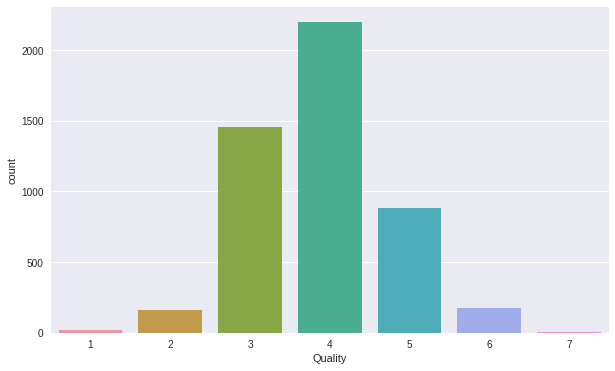

```python
plt.figure(figsize=(10, 6))
sns.countplot(csv['Quality'])
```

### 2.2 Data Spliting

We use cross validation to split data. The detail process will be shown in following contents.

Before choosing the model, we first consider to compare 2 cross validation method: K-fold and Straitified K-fold. K-fold method equally divided the sample into K groups of small samples. And each small sample will be used as testing data while the other K-1 groups will be used as training data. This means that the whole process will repeated K times. At the same time, all obsercations will be used for both training and testing.

But Straitified K-fold is different. Unlike K-fold equally dividing data, Straitified K-fold consider about imbalance in the sample data set. If one class appears more frequently than others, straitified K-fold will show this imbalance in later spliting.

In our case, it is easily to tell the imbalance between classes. Thus simply using K-fold strategy can be unreasonable. In order to guarantee the imbalance distribution of classes in original sample does cause incorrect validation in result, we use Straitified K-fold in our model.

```python
from sklearn.model_selection import StratifiedKFold, train_test_split
from sklearn.model_selection import cross_val_score
from sklearn.model_selection import cross_val_score
from sklearn.model_selection import KFold, ShuffleSplit
from sklearn.model_selection import StratifiedKFold, StratifiedShuffleSplit
from sklearn.metrics import make_scorer, accuracy_score
from sklearn.metrics import precision_score, recall_score, f1_score
from sklearn.linear_model import LogisticRegression
from sklearn.model_selection import GridSearchCV
from sklearn.pipeline import make_pipeline
```

```python
##X_train and y_train##
# if 'Quality' in csvdrop:
#     y=csvdrop['Quality'].values
#     del csvdrop['Quality']
#     X = csvdrop.values
X = csvdrop.drop('Quality', axis=1)
y = csvdrop['Quality']
```

```python
cv = StratifiedKFold(n_splits=5)
for train_index, test_index in cv.split(X, y):
   print("TRAIN:", train_index, "TEST:", test_index)
```

[output not shown]

[output cut: 337 more lines]

## 3. Modeling

### 3.1 Multi-layer perceptron

```python
epsilon = 1e-10 #add a small number to aviold log(o)
epsilon
```

```
1e-10
```

```python
from scipy.special import expit
import sys
from sklearn.metrics import accuracy_score


class MLPLayerPerceptronBase(object):
    def __init__(self, n_hidden=30,
                 C=0.0, epochs=500, eta=0.001, random_state=None, layer = 2, phi = 'sigmoid', f_cost = 'quadratic'):
        np.random.seed(random_state)
        self.n_hidden = n_hidden
        self.l2_C = C
        self.epochs = epochs
        self.eta = eta
        self.layer = layer
        self.phi = phi
        self.f_cost = f_cost

    @staticmethod
    def _encode_labels(y):
        """Encode labels into one-hot representation"""
        onehot = pd.get_dummies(y).values.T

        return onehot

    def _initialize_weights(self):
        """Initialize weights with small random numbers."""
        W = [None] * self.layer

        W_first_num_elems = (self.n_features_ + 1)*self.n_hidden
        W[0] = np.random.uniform(-1.0, 1.0, size = W_first_num_elems)
        W[0] = W[0].reshape(self.n_hidden, self.n_features_ + 1)

        W_last_num_elems = (self.n_hidden + 1)*self.n_output_
        W[self.layer - 1] = np.random.uniform(-1.0, 1.0, size = W_last_num_elems)
        W[self.layer - 1] = W[self.layer - 1].reshape(self.n_output_, self.n_hidden + 1)
        for i in range(1, self.layer - 1):
            W[i] = np.random.uniform(-1.0, 1.0, size=(self.n_hidden + 1)*self.n_hidden)
            W[i] = W[i].reshape(self.n_hidden, self.n_hidden + 1)


        return W

    @staticmethod
    def _sigmoid(z):
        """Use scipy.special.expit to avoid overflow"""
        return expit(z)
    def _linear(z):
        return z

    @staticmethod
    def _add_bias_unit(X, how='column'):
        """Add bias unit (column or row of 1s) to array at index 0"""
        if how == 'column':
            ones = np.ones((X.shape[0], 1))
            X_new = np.hstack((ones, X))
        elif how == 'row':
            ones = np.ones((1, X.shape[1]))
            X_new = np.vstack((ones, X))
        return X_new

    @staticmethod
    def _L2_reg(lambda_, W):
        """Compute L2-regularization cost"""
        # only compute for non-bias terms
        result = (lambda_/2.0) * np.sqrt(np.mean(W[0][:, 1:] ** 2))
        for i in range(1, len(W)):
            result = result + np.sqrt(np.mean(W[i][:, 1:] ** 2))
        return result

        #return (lambda_/2.0) * np.sqrt(np.mean(W1[:, 1:] ** 2) + np.mean(W2[:, 1:] ** 2))

    def _cost(self,A_list,Y_enc,W):
        '''Get the objective function value'''
        if self.f_cost == 'quadratic':
            cost = np.mean((Y_enc-A_list[-1]**2))
        elif self.f_cost == 'cross_entropy':
            cost = -np.mean(np.nan_to_num((Y_enc*np.log((A_list[-1])+(1-Y_enc)+epsilon))*np.log(1-A_list[-1]+epsilon)))
        L2_term = self._L2_reg(self.l2_C, W)
        return cost + L2_term
        #return cost

    def _feedforward(self, X, W):
        """Compute feedforward step
        """
        A_list = [None] * (len(W) + 1)
        Z_list = [None] * len(W)
        A = self._add_bias_unit(X, how='column')
        Z = W[0] @ A.T

        A_list[0] = A
        Z_list[0] = Z

        if self.phi == 'sigmoid':
            for i in range(1, len(W)):
                A_list[i] = self._sigmoid(Z_list[i - 1])
                A_list[i] = self._add_bias_unit(A_list[i], how='row')
                Z_list[i] = W[i] @ A_list[i]

            A_list[len(W)] = self._sigmoid(Z_list[len(W) - 1])

        elif self.phi == 'linear':
            for i in range(1, len(W)):
                #A_list[i] = self._linear(Z_list[i - 1])
                A_list[i] = Z_list[i - 1]
                A_list[i] = self._add_bias_unit(A_list[i], how='row')
                Z_list[i] = W[i] @ A_list[i]

            #A_list[len(W)] = self._linear(Z_list[len(W) - 1])
            A_list[len(W)] = Z_list[len(W) - 1]

        return A_list, Z_list

    def _get_gradient(self, A_list, Z_list, Y_enc, W):
        """ Compute gradient step using backpropagation.
        """
        sigma = [None] * len(W)
        if self.f_cost == 'quadratic':
            sigma[-1] = -2 * (Y_enc - A_list[-1]) * (A_list[-1]) * (1 - A_list[-1])
        elif self.f_cost == 'cross_entropy':
            sigma[-1] = (Y_enc - A_list[-1])
        if self.phi == 'sigmoid':
            sigma[-2] = (W[-1].T @ sigma[-1]) * A_list[-2] * (1 - A_list[-2])
            for i in range(len(sigma) - 3, -1, -1):
                sigma[i] = (W[i + 1].T @ sigma[i + 1][1:,:]) * A_list[i + 1] * (1 - A_list[i + 1])

        elif self.phi == 'linear':
            sigma[-2] = (W[-1].T @ sigma[-1])
            for i in range(len(sigma) - 3, -1, -1):
                sigma[i] = (W[i + 1].T @ sigma[i + 1][1:,:])

        #sigma[0] = (W[1].T @ sigma[1][1:, :]) * A_list[1] * (1- A_list[1])
        #sigma[1] = (W[1].T @ sigma[2][1:, :]) * A_list[2] * (1- A_list[2])
        #sigma[0] = (W[1].T @ sigma[1][1:, :]) * A_list[1] * (1- A_list[1]) ############################
        grad_list = [None] * (self.layer)
        grad_list[0] = sigma[0][1:,:] @ A_list[0]
        grad_list[len(grad_list) - 1] = sigma[len(grad_list) - 1] @ A_list[len(grad_list) - 1].T
        for i in range(1, len(grad_list) - 1):
            grad_list[i] = sigma[i][1:, :] @ A_list[i].T
        for i in range(len(grad_list)):
            grad_list[i][:, 1:] = W[i][:,1:] * self.l2_C
        return grad_list


    def predict(self, X):
        """Predict class labels"""
        A_list,Z_list = self._feedforward(X, self.W)
        y_pred = np.argmax(A_list[-1], axis=0)
        return y_pred

    def fit(self, X, y, print_progress=False):
        """ Learn weights from training data."""

        X_data, y_data = X.copy(), y.copy()
        Y_enc = self._encode_labels(y)

        self.W = []
        self.n_features_ = X_data.shape[1]
        self.n_output_ = Y_enc.shape[0]
        self.W = self._initialize_weights()

        self.cost_ = []
        self.score_ = []
        for i in range(self.epochs):

            if print_progress>0 and (i+1)%print_progress==0:
                sys.stderr.write('\rEpoch: %d/%d' % (i+1, self.epochs))
                sys.stderr.flush()


            A_list,Z_list = self._feedforward(X_data,self.W)

            cost = self._cost(A_list,Y_enc,self.W)
            self.cost_.append(cost)

            # compute the gradient
            grad_list = self._get_gradient(A_list, Z_list, Y_enc, self.W)

            self.W[0] -= self.eta * grad_list[0]
            self.W[len(self.W) - 1] -= self.eta * grad_list[len(self.W) - 1]
            for i in range(len(self.W)):
                self.W[i] -= self.eta * grad_list[i]
            self.score_.append(f1_score(y_data,self.predict(X_data),average='micro'))
        return self
    def get_params(self, deep=True):
        return {
            'eta': self.eta, 'C': self.l2_C,"phi": self.phi,
            'f_cost': self.f_cost, 'layer': self.layer,
            'n_hidden': self.n_hidden, 'epochs': self.epochs
        }
    def set_params(self, **parameters):
        for parameter, value in parameters.items():
            self.__setattr__(parameter, value)
        return self
```

```
(-0.005922528032619776, 0.4589795918367347)
```

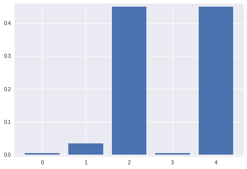

```python
##Pick a phi and a loss function to see the perfermance of f1 score##
##Test MLP implementation as did in ICA4##
mlp = MLPLayerPerceptronBase(random_state=1,
                             n_hidden=1,
                             layer=2,
                             epochs=200,
                             phi="linear",
                             eta=0.00001,
                             f_cost="cross_entropy",
                             C=0.1
                            )
# Use f1 score with micro average as evaluation criteria
my_scorer = make_scorer(f1_score, average='micro')
per_fold_eval_criteria = cross_val_score(estimator=mlp,
                                    X=X,
                                    y=y,
                                    cv=cv,
                                    scoring=my_scorer
                                   )

plt.bar(range(len(per_fold_eval_criteria)),per_fold_eval_criteria)
plt.ylim([min(per_fold_eval_criteria)-0.01,max(per_fold_eval_criteria)+0.01])
```

Note that the output is different everytime The result is not as good as we expected since f-1 score is smaller than 0.5, but it is acceptable.

### 3.2 Hyper-Parameters Tunning

```python
parameters = {'f_cost':['quadratic','cross_entropy'], 'phi':['linear','sigmoid'], 'eta': [0.00001], 'epochs': [200], 'layer':[2,4,8], 'n_hidden':[5], 'C':[0.001] }

mlp = MLPLayerPerceptronBase()
my_scorer = make_scorer(f1_score, average='micro')
clf = GridSearchCV(mlp,
                   parameters,
                   scoring=my_scorer,
                   cv=cv
                  )
clf.fit(X, y, print_progress=5)
```

```
Epoch: 200/200
```

```
GridSearchCV(cv=StratifiedKFold(n_splits=5, random_state=None, shuffle=False),
       error_score='raise',
       estimator=<__main__.MLPLayerPerceptronBase object at 0x7f321e246a58>,
       fit_params=None, iid=True, n_jobs=1,
       param_grid={'f_cost': ['quadratic', 'cross_entropy'], 'phi': ['linear', 'sigmoid'], 'eta': [1e-05], 'epochs': [200], 'layer': [2, 4, 8], 'n_hidden': [5], 'C': [0.001]},
       pre_dispatch='2*n_jobs', refit=True, return_train_score='warn',
       scoring=make_scorer(f1_score, average=micro), verbose=0)
```

```python
plot = pd.DataFrame(clf.cv_results_)
pd.set_option('display.max_columns', None)
plot
```

|  | mean_fit_time | mean_score_time | mean_test_score | mean_train_score | param_C | param_epochs | param_eta | param_f_cost | param_layer | param_n_hidden | param_phi | params | rank_test_score | split0_test_score | split0_train_score | split1_test_score | split1_train_score | split2_test_score | split2_train_score | split3_test_score | split3_train_score | split4_test_score | split4_train_score | std_fit_time | std_score_time | std_test_score | std_train_score |
| --- | --- | --- | --- | --- | --- | --- | --- | --- | --- | --- | --- | --- | --- | --- | --- | --- | --- | --- | --- | --- | --- | --- | --- | --- | --- | --- | --- |
| 0 | 0.638910 | 0.001511 | 0.000000 | 0.000000 | 0.001 | 200 | 1e-05 | quadratic | 2 | 5 | linear | {'C': 0.001, 'epochs': 200, 'eta': 1e-05, 'f_c... | 10 | 0.000000 | 0.000000 | 0.000000 | 0.000000 | 0.000000 | 0.000000 | 0.000000 | 0.000000 | 0.000000 | 0.000000 | 0.026318 | 0.000389 | 0.000000 | 0.000000 |
| 1 | 1.155656 | 0.001680 | 0.297877 | 0.297009 | 0.001 | 200 | 1e-05 | quadratic | 2 | 5 | sigmoid | {'C': 0.001, 'epochs': 200, 'eta': 1e-05, 'f_c... | 1 | 0.297655 | 0.297421 | 0.297655 | 0.297421 | 0.298980 | 0.295304 | 0.297546 | 0.297449 | 0.297546 | 0.297449 | 0.011519 | 0.000384 | 0.000554 | 0.000853 |
| 2 | 0.815719 | 0.001558 | 0.000000 | 0.000000 | 0.001 | 200 | 1e-05 | quadratic | 4 | 5 | linear | {'C': 0.001, 'epochs': 200, 'eta': 1e-05, 'f_c... | 10 | 0.000000 | 0.000000 | 0.000000 | 0.000000 | 0.000000 | 0.000000 | 0.000000 | 0.000000 | 0.000000 | 0.000000 | 0.007608 | 0.000255 | 0.000000 | 0.000000 |
| 3 | 1.663784 | 0.001952 | 0.297468 | 0.297468 | 0.001 | 200 | 1e-05 | quadratic | 4 | 5 | sigmoid | {'C': 0.001, 'epochs': 200, 'eta': 1e-05, 'f_c... | 2 | 0.297655 | 0.297421 | 0.297655 | 0.297421 | 0.296939 | 0.297601 | 0.297546 | 0.297449 | 0.297546 | 0.297449 | 0.016261 | 0.000325 | 0.000269 | 0.000067 |
| 4 | 1.120867 | 0.001908 | 0.000000 | 0.000000 | 0.001 | 200 | 1e-05 | quadratic | 8 | 5 | linear | {'C': 0.001, 'epochs': 200, 'eta': 1e-05, 'f_c... | 10 | 0.000000 | 0.000000 | 0.000000 | 0.000000 | 0.000000 | 0.000000 | 0.000000 | 0.000000 | 0.000000 | 0.000000 | 0.005112 | 0.000267 | 0.000000 | 0.000000 |
| 5 | 2.738650 | 0.002272 | 0.244794 | 0.244584 | 0.001 | 200 | 1e-05 | quadratic | 8 | 5 | sigmoid | {'C': 0.001, 'epochs': 200, 'eta': 1e-05, 'f_c... | 3 | 0.297655 | 0.297421 | 0.297655 | 0.297421 | 0.033673 | 0.033180 | 0.297546 | 0.297449 | 0.297546 | 0.297449 | 0.011854 | 0.000044 | 0.105587 | 0.105702 |
| 6 | 0.904913 | 0.001248 | 0.086158 | 0.086181 | 0.001 | 200 | 1e-05 | cross_entropy | 2 | 5 | linear | {'C': 0.001, 'epochs': 200, 'eta': 1e-05, 'f_c... | 6 | 0.179409 | 0.179729 | 0.179409 | 0.179729 | 0.035714 | 0.035733 | 0.035787 | 0.035714 | 0.000000 | 0.000000 | 0.010994 | 0.000263 | 0.077338 | 0.077488 |
| 7 | 1.453374 | 0.001417 | 0.115557 | 0.115671 | 0.001 | 200 | 1e-05 | cross_entropy | 2 | 5 | sigmoid | {'C': 0.001, 'epochs': 200, 'eta': 1e-05, 'f_c... | 5 | 0.179409 | 0.179729 | 0.179409 | 0.179729 | 0.035714 | 0.035733 | 0.178937 | 0.179082 | 0.004090 | 0.004082 | 0.008021 | 0.000219 | 0.078687 | 0.078829 |
| 8 | 1.076620 | 0.001545 | 0.050633 | 0.050516 | 0.001 | 200 | 1e-05 | cross_entropy | 4 | 5 | linear | {'C': 0.001, 'epochs': 200, 'eta': 1e-05, 'f_c... | 7 | 0.033639 | 0.033189 | 0.004077 | 0.004085 | 0.000000 | 0.000000 | 0.179959 | 0.179592 | 0.035787 | 0.035714 | 0.007241 | 0.000076 | 0.066246 | 0.066163 |
| 9 | 1.938881 | 0.001586 | 0.044712 | 0.044695 | 0.001 | 200 | 1e-05 | cross_entropy | 4 | 5 | sigmoid | {'C': 0.001, 'epochs': 200, 'eta': 1e-05, 'f_c... | 8 | 0.004077 | 0.004085 | 0.004077 | 0.004085 | 0.000000 | 0.000000 | 0.179959 | 0.179592 | 0.035787 | 0.035714 | 0.008578 | 0.000041 | 0.068773 | 0.068664 |
| 10 | 1.369595 | 0.001470 | 0.015108 | 0.015103 | 0.001 | 200 | 1e-05 | cross_entropy | 8 | 5 | linear | {'C': 0.001, 'epochs': 200, 'eta': 1e-05, 'f_c... | 9 | 0.000000 | 0.000000 | 0.004077 | 0.004085 | 0.000000 | 0.000000 | 0.035787 | 0.035714 | 0.035787 | 0.035714 | 0.014134 | 0.000143 | 0.016927 | 0.016895 |
| 11 | 3.016663 | 0.002296 | 0.115762 | 0.115746 | 0.001 | 200 | 1e-05 | cross_entropy | 8 | 5 | sigmoid | {'C': 0.001, 'epochs': 200, 'eta': 1e-05, 'f_c... | 4 | 0.179409 | 0.179729 | 0.004077 | 0.004085 | 0.035714 | 0.035733 | 0.179959 | 0.179592 | 0.179959 | 0.179592 | 0.017418 | 0.000047 | 0.078978 | 0.078888 |

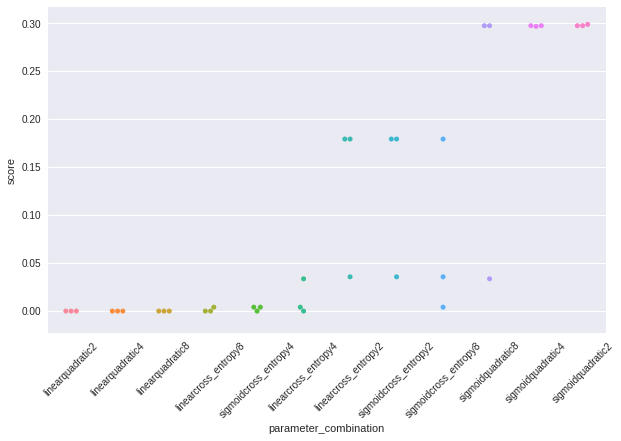

```python
plot['parameter_combination'] = plot.param_phi.astype(str) + plot.param_f_cost.astype(str) + plot.param_layer.astype(str)
plot.sort_values(by='mean_test_score', inplace=True)
newplot = plot.melt(id_vars=['parameter_combination'],
                           value_vars=['split0_test_score','split1_test_score','split2_test_score'],
                           value_name='score')

plt.figure(figsize=(10, 6))
sns.swarmplot(data=newplot, x='parameter_combination', y='score')
plt.xticks(rotation=45)
plt.show()
##generated by {'f_cost':['quadratic','cross_entropy'], 'phi':['linear','sigmoid'], 'eta': [0.00001], 'epochs': [200], 'layer':[2,4,8], 'n_hidden':[5], 'C':[0.001] }##
```

The best f1 score appear at

phi: sigmoid

cost_function:quadratic

layer:2

### 3.3 Magnitude of the Gradients

```python
##state a new class##
class MLPlayergradients(MLPLayerPerceptronBase) :
    def __init__(self, n_hidden=5,
                 C=0.001, epochs=20, eta=0.00001, random_state=None, layer = 4, phi = 'linear', f_cost = 'cross_entropy'):
        np.random.seed(random_state)
        self.n_hidden = n_hidden
        self.l2_C = C
        self.epochs = epochs
        self.eta = eta
        self.layer = layer
        self.phi = phi
        self.f_cost = f_cost
        #self.grad[i] = [None] * layer


    def fit(self, X, y, print_progress=False):
        """ Learn weights from training data."""

        X_data, y_data = X.copy(), y.copy()
        Y_enc = self._encode_labels(y)
        #grad_w = [None] * self.layer
        #####for i in range(self.layer):
        #####    grad_w[i] = list()
        self.W = []
        self.n_features_ = X_data.shape[1]
        self.n_output_ = Y_enc.shape[0]
        self.W = self._initialize_weights()

        self.cost_ = []
        self.score_ = []
        for i in range(self.epochs):

            if print_progress>0 and (i+1)%print_progress==0:
                sys.stderr.write('\rEpoch: %d/%d' % (i+1, self.epochs))
                sys.stderr.flush()

            # feedforward all instances
            A_list,Z_list = self._feedforward(X_data,self.W)

            cost = self._cost(A_list,Y_enc,self.W)
            self.cost_.append(cost)

            # compute gradient
            grad_list = self._get_gradient(A_list, Z_list, Y_enc, self.W)

            self.W[0] -= self.eta * grad_list[0]
            self.W[len(self.W) - 1] -= self.eta * grad_list[len(self.W) - 1]
            for i in range(len(self.W)):
                self.W[i] -= self.eta * grad_list[i]
                grad[i].append(np.mean(grad_list[i]))
            self.score_.append(f1_score(y_data,self.predict(X_data),average='micro'))
        for i in range(self.layer):
            grad[i]=np.array(grad[i])
            print(grad[i])
        return self
```

```python
parameter = dict(n_hidden=2,
              C=0.001,
              epochs=100, ##use a great epochs to see the change
              eta=0.00001,
              random_state=1,
              layer = 3,
              phi = 'sigmoid',
              f_cost = 'quadratic'
              )
##to see the difference between 8 layers##
```

```python
##get all 500 gradients for all 8 layers##

grad = [None] * 3
for i in range(3):
    grad[i] = list()
gradients = MLPlayergradients(**parameter)
gradient = gradients.fit(X, y, print_progress=5)
##scroll down##
```

```
Epoch: 100/100
```

```
[-0.00020424 -0.00020424 -0.00020423 -0.00020423 -0.00020423 -0.00020423
 -0.00020422 -0.00020422 -0.00020422 -0.00020422 -0.00020421 -0.00020421
 -0.00020421 -0.00020421 -0.0002042  -0.0002042  -0.0002042  -0.0002042
 -0.0002042  -0.00020419 -0.00020419 -0.00020419 -0.00020419 -0.00020419
 -0.00020419 -0.00020419 -0.00020419 -0.00020418 -0.00020418 -0.00020418
 -0.00020418 -0.00020418 -0.00020418 -0.00020418 -0.00020418 -0.00020418
 -0.00020418 -0.00020418 -0.00020418 -0.00020418 -0.00020418 -0.00020418
 -0.00020418 -0.00020418 -0.00020418 -0.00020418 -0.00020418 -0.00020418
 -0.00020418 -0.00020419 -0.00020419 -0.00020419 -0.00020419 -0.00020419
 -0.00020419 -0.00020419 -0.00020419 -0.00020419 -0.00020419 -0.00020419
 -0.00020419 -0.00020419 -0.00020419 -0.0002042  -0.0002042  -0.0002042
 -0.0002042  -0.0002042  -0.0002042  -0.0002042  -0.0002042  -0.0002042
 -0.0002042  -0.0002042  -0.00020421 -0.00020421 -0.00020421 -0.00020421
 -0.00020421 -0.00020421 -0.00020421 -0.00020421 -0.00020421 -0.00020421
 -0.00020421 -0.00020422 -0.00020422 -0.00020422 -0.00020422 -0.00020422
 -0.00020422 -0.00020422 -0.00020422 -0.00020422 -0.00020422 -0.00020422
 -0.00020422 -0.00020422 -0.00020423 -0.00020423]
[-2.43480397 -1.2964603  -0.17007364  0.94247066  2.03931443  3.11863738
  4.17866757  5.21769149  6.23406374  7.22621625  8.19266684  9.13202718
 10.04301005 10.92443582 11.77523804 12.59446824 13.38129972 14.13503039
 14.85508465 15.54101416 16.19249765 16.80933968 17.39146837 17.93893218
 18.45189578 18.93063498 19.37553099 19.78706385 20.16580543 20.51241175
 20.82761511 21.11221582 21.36707387 21.59310055 21.79125015 21.96251181
 22.10790167 22.22845538 22.32522098 22.39925226 22.45160266 22.48331966
 22.4954398  22.48898412 22.46495433 22.42432941 22.36806274 22.29707979
 22.21227623 22.11451644 22.00463254 21.88342362 21.75165543 21.61006024
 21.45933708 21.30015203 21.13313886 20.95889967 20.77800578 20.59099864
 20.39839084 20.20066715 19.99828565 19.79167886 19.58125483 19.3673983
 19.15047181 18.93081678 18.70875461 18.48458771 18.25860048 18.03106031
 17.8022185  17.57231114 17.34155996 17.11017313 16.87834604 16.64626201
 16.41409299 16.18200018 15.95013466 15.71863799 15.48764271 15.25727285
 15.02764446 14.79886602 14.57103886 14.34425759 14.11861046 13.8941797
 13.67104188 13.44926818 13.22892474 13.01007288 12.79276941 12.57706684
 12.3630136  12.1506543  11.94002992 11.73117797]
[252.91493203 251.90433282 250.86114945 249.78495512 248.67532173
 247.53182355 246.35404231 245.14157355 243.89403412 242.61107089
 241.29237025 239.93766836 238.54676187 237.11951884 235.65588958
 234.15591716 232.61974728 231.04763724 229.43996373 227.79722927
 226.12006703 224.40924398 222.66566211 220.89035781 219.08449931
 217.24938224 215.38642341 213.49715289 211.5832046  209.64630567
 207.68826459 205.71095864 203.71632068 201.70632559 199.68297669
 197.6482922  195.60429213 193.55298568 191.49635938 189.43636599
 187.37491451 185.31386104 183.25500086 181.20006154 179.15069718
 177.10848376 175.07491549 173.0514022  171.03926762 169.03974857
 167.05399486 165.08306996 163.12795224 161.18953672 159.26863738
 157.36598965 155.48225344 153.61801622 151.77379636 149.95004659
 148.1471575  146.36546113 144.60523447 142.86670303 141.15004422
 139.45539076 137.78283392 136.13242663 134.50418655 132.89809888
 131.31411913 129.75217569 128.21217231 126.69399034 125.19749095
 123.72251709 122.26889545 120.83643814 119.42494439 118.03420199
 116.66398878 115.31407385 113.9842188  112.6741788  111.3837036
 110.11253846 108.860425   107.62710195 106.41230586 105.21577173
 104.03723363 102.87642515 101.73307995 100.60693214  99.4977167
  98.40516977  97.32902903  96.26903394  95.22492596  94.19644883]
```

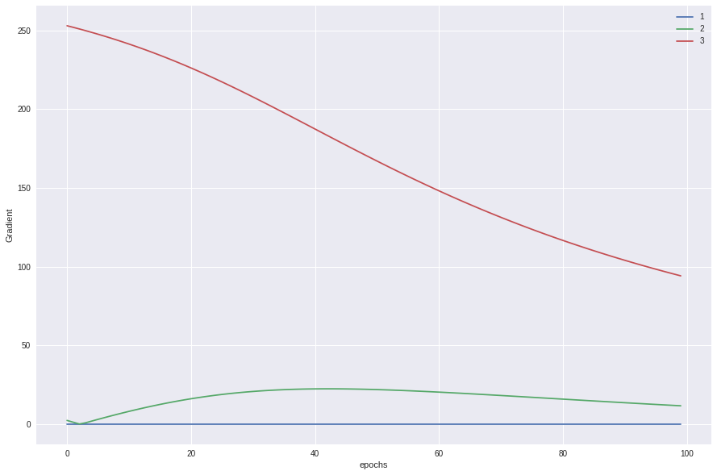

```python
##plot##
plt.figure(figsize=(15, 10))
for i in range(3):
    plt.plot(abs(grad[i]), label=i+1)

plt.legend()
plt.ylabel('Gradient')
plt.xlabel('epochs')
plt.show()
```

The gradients in 3 layers are shown on the above plot. For layer 1, the magnitudes of gradients stay consistently at initiated value 0. It means the model is not learning in the first layer. For layer 2 and 3, the gradients are not consistent. The gradients of layer 2 first increase then decrease slowly. The gradients of layer 3 decrease along with the increase of epochs.

## 5. Refence

https://archive.ics.uci.edu/ml/datasets/wine+quality

https://github.com/eclarson/MachineLearningNotebooks

Gradient calculation part reference: https://github.com/carterkoehler/evaluation-and-mlp/blob/master/notebooks/cover-type.ipynb